# Survival-Final Version

# Libraries and Dataset

```r
setwd("C:/Users/Utente/Desktop/NPS/Projects/git_clone/boardgames-nps-project/survival")

# Loading necessary libraries
library(survival)
library(survminer)
library(dplyr)
library(ggplot2)
library(knitr)
library(broom)
library(tidyr)
library(splines)
library(rms)
library(survminer)

# Import the dataset
data <- read.csv("C:/Users/Utente/Desktop/NPS/Projects/git_clone/boardgames-nps-project/survival/survival_final.csv")
View(data)

# Remove zombies (i.e., ancient games that are already dead at the beginning of our time-window)
# 1 month:
data <- data[data$time != 31, ]
```

# Initial analysis

```r
# Initial analysis
str(data$id) #check that id is a factor
```

```
 int [1:19936] 1 2 3 4 5 6 7 8 9 10 ...
```

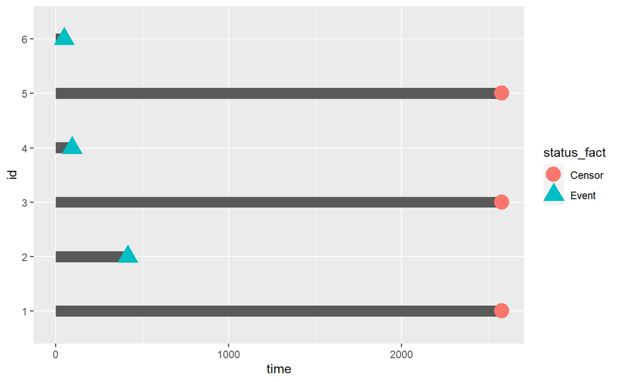

```r
data$id=as.factor(data$id)
data$status_fact=factor(data$status, labels = (c('Censor', 'Event'))) #=delta_i
data_subs = head(data)

#Plot:
ggplot(data=data_subs,aes(x=id,y=time)) +
  geom_bar(stat='identity',width=0.2) +
  geom_point(aes(color=status_fact,shape=status_fact),size=6) +
  coord_flip()
```

```r
# Survival object
head(Surv(time=data$time, event=data$status==2))
```

```
[1] 2579+  417  2579+   94  2579+   49
```

# KAPLAN-MEIER ESTIMATOR

```r
# KAPLAN-MEIER ESTIMATOR FOR SURVIVAL CURVES
fit=survfit(Surv(time, status==2) ~1, data=data)
summary(fit)
```

```
Call: survfit(formula = Surv(time, status == 2) ~ 1, data = data)

 time n.risk n.event survival  std.err lower 95% CI upper 95% CI
    1  19936       6    1.000 0.000123        0.999        1.000
    3  19930       2    1.000 0.000142        0.999        1.000
    4  19928       1    1.000 0.000150        0.999        1.000
    5  19927       1    0.999 0.000159        0.999        1.000
    6  19926       3    0.999 0.000181        0.999        1.000
    7  19923       4    0.999 0.000207        0.999        1.000
    8  19919       1    0.999 0.000213        0.999        1.000
    9  19918       4    0.999 0.000235        0.998        0.999
   10  19914       5    0.999 0.000260        0.998        0.999
   11  19909       1    0.999 0.000265        0.998        0.999
   12  19908       3    0.998 0.000279        0.998        0.999
   13  19905       4    0.998 0.000296        0.998        0.999
```

[output cut: 131 more lines]

```r
kable(head(tidy(fit),20))
```

| time | n.risk | n.event | n.censor | estimate | std.error | conf.high | conf.low |
| --- | --- | --- | --- | --- | --- | --- | --- |
| 1 | 19936 | 6 | 0 | 0.9996990 | 0.0001229 | 0.9999398 | 0.9994583 |
| 3 | 19930 | 2 | 0 | 0.9995987 | 0.0001419 | 0.9998768 | 0.9993207 |
| 4 | 19928 | 1 | 0 | 0.9995486 | 0.0001505 | 0.9998435 | 0.9992537 |
| 5 | 19927 | 1 | 0 | 0.9994984 | 0.0001587 | 0.9998093 | 0.9991876 |
| 6 | 19926 | 3 | 0 | 0.9993479 | 0.0001809 | 0.9997023 | 0.9989936 |
| 7 | 19923 | 4 | 0 | 0.9991473 | 0.0002069 | 0.9995525 | 0.9987422 |
| 8 | 19919 | 1 | 0 | 0.9990971 | 0.0002129 | 0.9995141 | 0.9986803 |
| 9 | 19918 | 4 | 0 | 0.9988965 | 0.0002354 | 0.9993574 | 0.9984357 |
| 10 | 19914 | 5 | 0 | 0.9986457 | 0.0002608 | 0.9991563 | 0.9981353 |
| 11 | 19909 | 1 | 0 | 0.9985955 | 0.0002656 | 0.9991155 | 0.9980758 |
| 12 | 19908 | 3 | 0 | 0.9984450 | 0.0002795 | 0.9989921 | 0.9978982 |
| 13 | 19905 | 4 | 0 | 0.9982444 | 0.0002970 | 0.9988257 | 0.9976634 |
| 15 | 19901 | 4 | 0 | 0.9980437 | 0.0003136 | 0.9986573 | 0.9974306 |
| 16 | 19897 | 4 | 0 | 0.9978431 | 0.0003293 | 0.9984873 | 0.9971993 |
| 17 | 19893 | 6 | 0 | 0.9975421 | 0.0003516 | 0.9982297 | 0.9968550 |
| 18 | 19887 | 2 | 0 | 0.9974418 | 0.0003587 | 0.9981433 | 0.9967409 |
| 19 | 19885 | 5 | 0 | 0.9971910 | 0.0003759 | 0.9979260 | 0.9964566 |
| 20 | 19880 | 9 | 0 | 0.9967396 | 0.0004051 | 0.9975312 | 0.9959486 |
| 21 | 19871 | 8 | 0 | 0.9963383 | 0.0004294 | 0.9971771 | 0.9955002 |
| 22 | 19863 | 4 | 0 | 0.9961376 | 0.0004410 | 0.9969990 | 0.9952770 |

```r
surv_median(fit)
```

| strata | median | lower | upper |
| --- | --- | --- | --- |
| All | 153 | 150 | 156 |

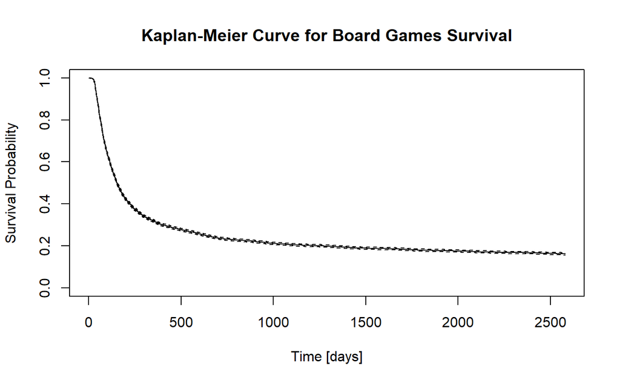

```r
#Plots:
#1)
plot(fit, conf.int = T, xlab='Time [days]', ylab = 'Survival Probability', palette='#55A36F',
     main="Kaplan-Meier Curve for Board Games Survival")
```

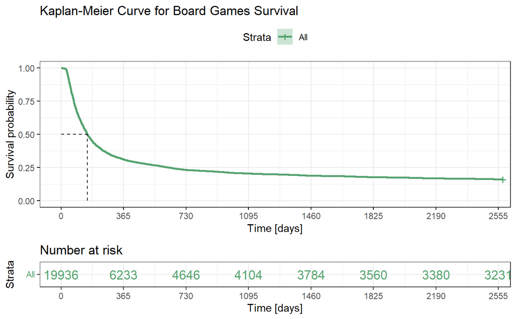

```r
#2)
ggsurvplot(fit, data=data,
           risk.table = TRUE, # Add risk table
           risk.table.col = "strata", # Change risk table color by groups
           surv.median.line = "hv", # Specify median survival
           ggtheme = theme_bw(), # Change ggplot2 theme
           break.time.by=365,
           title="Kaplan-Meier Curve for Board Games Survival", xlab="Time [days]", palette='#55A36F')
```

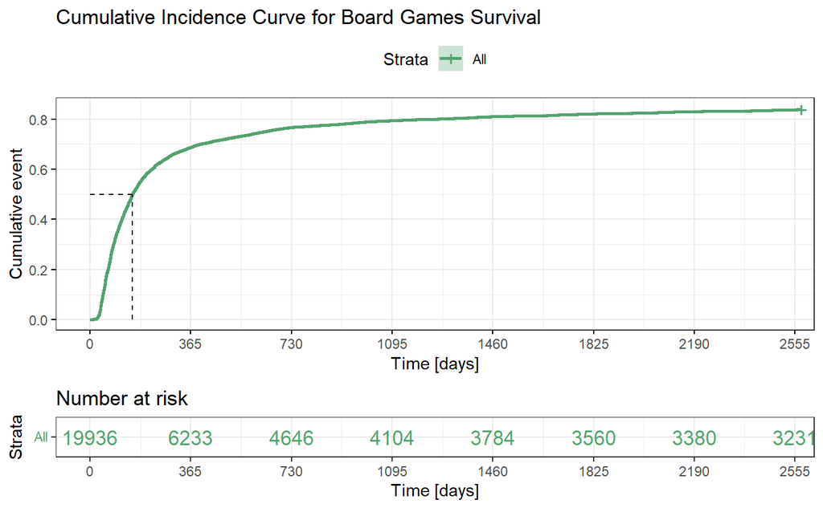

```r
## Cumulative Failure Probability
cumulative_incidence=1-fit$surv

#Plot:
ggsurvplot(fit, data=data,
           risk.table = TRUE, # Add risk table
           risk.table.col = "strata", # Change risk table color by groups
           surv.median.line = "hv", # Specify median survival
           ggtheme = theme_bw(), # Change ggplot2 theme
           break.time.by=365,
           fun='event',
           title="Cumulative Incidence Curve for Board Games Survival", xlab="Time [days]", palette='#55A36F')
```

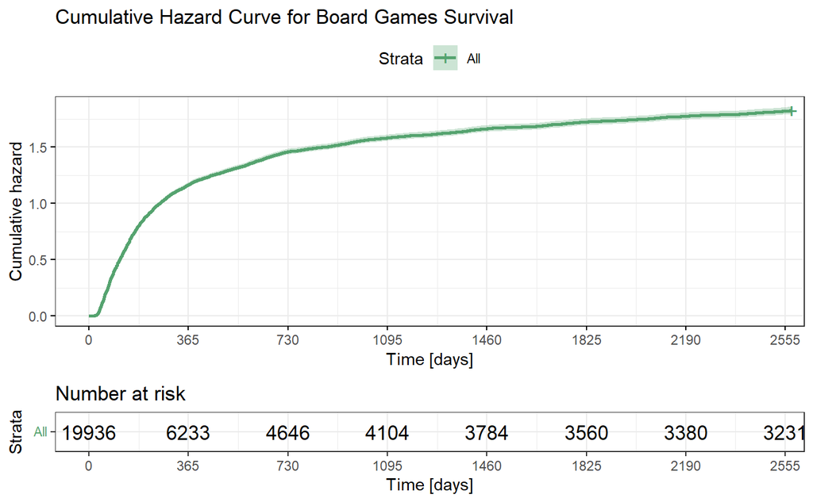

```r
## Hazard function
H=fit$cumhaz

#Plot:
ggsurvplot(fit, data=data,
           risk.table = TRUE, # Add risk table
           ggtheme = theme_bw(), # Change ggplot2 theme
           break.time.by=365,
           fun='cumhaz',
           title="Cumulative Hazard Curve for Board Games Survival",
           xlab="Time [days]", palette='#55A36F')
```

# KAPLAN-MEIER CURVES FOR CATEGORIES

## 1)Economic category

At this stage, we construct Kaplan-Meier curves to compare the Economic category versus all others.

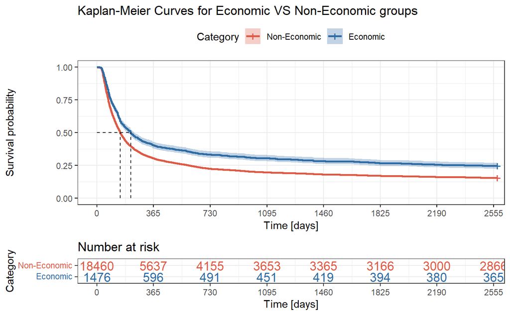

```r
#1) Economic:
data$id=as.factor(data$id)
data$Economic_fact=factor(data$Economic, labels = (c('Non-Economic', 'Economic')))

fit.economic=survfit(Surv(time, status) ~ Economic_fact, data=data)

#Plot:
ggsurvplot(fit.economic, data=data, conf.int = T,
           risk.table = TRUE, # Add risk table
           risk.table.col = "strata", # Change risk table color by groups
           surv.median.line = "hv", # Specify median survival
           ggtheme = theme_bw(), # Change ggplot2 theme
           break.time.by=365,
           legend.labs=c("Non-Economic","Economic"), legend.title="Category",
           palette=c("#DE5A45","#2F6CA3"),
           title="Kaplan-Meier Curves for Economic VS Non-Economic groups",
           xlab="Time [days]")
```

## 2) All the categories (one-at-the-time)

Now, we follow the prevoius example on the Economic category, repeating the same procedure for all the categories. Note that we report a comparison of the categories one-at-the-time. Move to the Cox model to investigate the the complete framework.

```r
#2) All the categories:
columns_of_interest <- colnames(data)[17:100]
plot_list=list()
for (col in columns_of_interest) {

  data[[paste0(col, "_fact")]] = factor(data[[col]], labels = c('No', 'Yes'))
  covariate=data[,ncol(data)]
  fit = survfit(Surv(time, status) ~ covariate, data = data)

  # Plot
  plot=ggsurvplot(fit, data = data, conf.int = TRUE,
             risk.table = TRUE, risk.table.col = "strata",
             surv.median.line = "hv", ggtheme = theme_bw(),
             break.time.by = 365,
             legend.labs = c("No", "Yes"), legend.title = "Category",
             palette = c("#DE5A45","#2F6CA3"),
             title = paste("Kaplan-Meier Curves for", col),
             xlab = "Time [days]")
  plot_list[[col]] = plot
}

length(plot_list) #84

pdf("survival_final_cat_km.pdf")
for (i in seq_along(plot_list)) {
  print(plot_list[[i]])
}
dev.off()
```

## LOG-RANK TEST and HR

### 1) Economic

Again, as a first step, we consider only the Economic category and proceed by applying both the usual log-rank test and the HR to further inspect previous results.

```r
#A)USUAL WAY: CHI-SQUARE DISTRIBUTION:
#H0: S1==S2  vs   H1:S1!= S2
#1)Economic:
log_rank_test_economic=survdiff(Surv(time, status) ~ Economic_fact, data=data)
log_rank_test_economic #p= <2e-16 --> sign difference
```

```
Call:
survdiff(formula = Surv(time, status) ~ Economic_fact, data = data)

                      N Observed Expected (O-E)^2/E (O-E)^2/V
Economic_fact=No  18460    15604    15256      7.93      91.4
Economic_fact=Yes  1476     1111     1459     82.96      91.4

 Chisq= 91.4  on 1 degrees of freedom, p= <2e-16
```

```r
hazard_ratio_economic = (log_rank_test_economic$obs[1]/log_rank_test_economic$exp[1])/(log_rank_test_economic$obs[2]/log_rank_test_economic$exp[2])
hazard_ratio_economic #1.343082 > 1 --> Being in the Non-Economic category is a risk factor
```

```
[1] 1.343082
```

### 2) All the categories

```r
#2)All the categories:
for (i in 105:188) {
  covariate=data[,i]
  print(colnames(data)[i])
  log_rank_test= survdiff(Surv(time, status) ~ covariate, data=data)
  print(log_rank_test)
  hazard_ratio = (log_rank_test$obs[1]/log_rank_test$exp[1])/(log_rank_test$obs[2]/log_rank_test$exp[2])
  print(hazard_ratio)

}
```

```
[1] "Economic_fact"
Call:
survdiff(formula = Surv(time, status) ~ covariate, data = data)

                  N Observed Expected (O-E)^2/E (O-E)^2/V
covariate=No  18460    15604    15256      7.93      91.4
covariate=Yes  1476     1111     1459     82.96      91.4

 Chisq= 91.4  on 1 degrees of freedom, p= <2e-16
[1] 1.343082
[1] "Negotiation_fact"
Call:
survdiff(formula = Surv(time, status) ~ covariate, data = data)

                  N Observed Expected (O-E)^2/E (O-E)^2/V
covariate=No  19333    16212    16190    0.0298     0.954
covariate=Yes   603      503      525    0.9200     0.954

 Chisq= 1  on 1 degrees of freedom, p= 0.3
[1] 1.045108
[1] "Political_fact"
Call:
survdiff(formula = Surv(time, status) ~ covariate, data = data)

                  N Observed Expected (O-E)^2/E (O-E)^2/V
covariate=No  19471    16351    16284     0.275      10.7
covariate=Yes   465      364      431    10.396      10.7

 Chisq= 10.7  on 1 degrees of freedom, p= 0.001
[1] 1.188744
[1] "Card.Game_fact"
Call:
survdiff(formula = Surv(time, status) ~ covariate, data = data)

                  N Observed Expected (O-E)^2/E (O-E)^2/V
covariate=No  13876    11752    11395      11.2      35.3
covariate=Yes  6060     4963     5320      24.0      35.3

 Chisq= 35.3  on 1 degrees of freedom, p= 3e-09
[1] 1.105544
```

[output cut: 785 more lines]

```
covariate=No  19917    16698  16700.1  0.000266       0.3
covariate=Yes    19       17     14.9  0.298446       0.3

 Chisq= 0.3  on 1 degrees of freedom, p= 0.6
[1] 0.8758791
[1] "Fan.Expansion_fact"
Call:
survdiff(formula = Surv(time, status) ~ covariate, data = data)

                  N Observed Expected (O-E)^2/E (O-E)^2/V
covariate=No  19935    16715 16713.18  0.000198      1.83
covariate=Yes     1        0     1.82  1.819699      1.83

 Chisq= 1.8  on 1 degrees of freedom, p= 0.2
[1] Inf
```

# COX MODEL

## a) Continuous variables

In this section we construct: a) a cox model for each covariate separately b) a cox model for all the numerical variables together

We build many variations of the same model, starting from the classical version and moving to a splines introduction.

### 1.A) Year

```r
#1.A)Year:
#lin:
cox.year <- coxph(Surv(time, status) ~ Year, data = data)
cox.year
```

```
Call:
coxph(formula = Surv(time, status) ~ Year, data = data)

           coef  exp(coef)   se(coef)      z      p
Year -0.0190655  0.9811151  0.0005332 -35.76 <2e-16

Likelihood ratio test=1126  on 1 df, p=< 2.2e-16
n= 19936, number of events= 16715
```

```r
summary(cox.year)
```

```
Call:
coxph(formula = Surv(time, status) ~ Year, data = data)

  n= 19936, number of events= 16715

           coef  exp(coef)   se(coef)      z Pr(>|z|)
Year -0.0190655  0.9811151  0.0005332 -35.76   <2e-16 ***
---
Signif. codes:  0 ‘***’ 0.001 ‘**’ 0.01 ‘*’ 0.05 ‘.’ 0.1 ‘ ’ 1

     exp(coef) exp(-coef) lower .95 upper .95
Year    0.9811      1.019    0.9801    0.9821

Concordance= 0.59  (se = 0.002 )
Likelihood ratio test= 1126  on 1 df,   p=<2e-16
Wald test            = 1278  on 1 df,   p=<2e-16
Score (logrank) test = 1297  on 1 df,   p=<2e-16
```

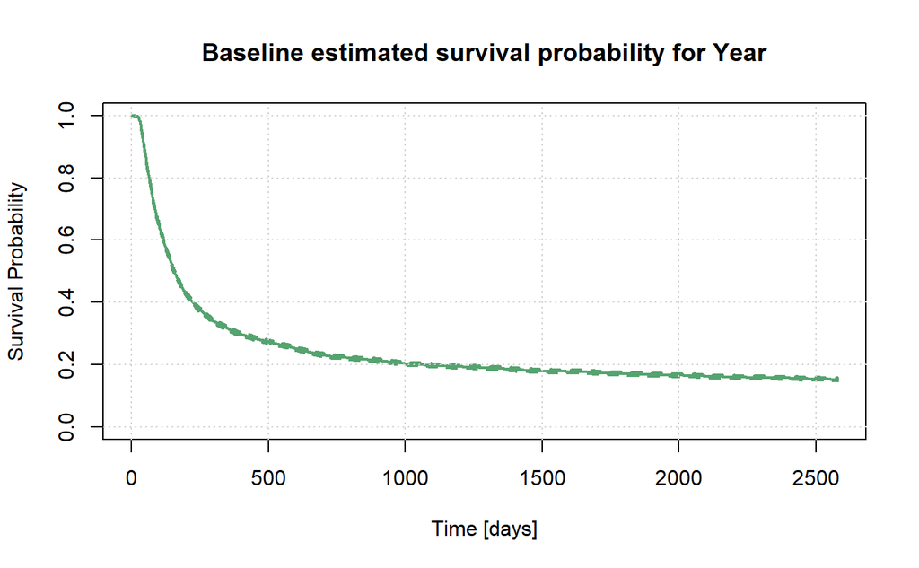

```r
#Plot (baseline survival function S0(t)):
plot(survfit(cox.year, data=data),
     col="#55A36F", lwd=2, lty=1,
     xlab='Time [days]', ylab='Survival Probability',
     main='Baseline estimated survival probability for Year')
grid()
```

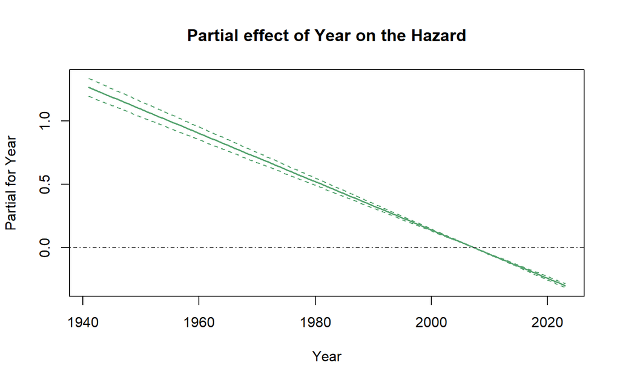

```r
termplot(cox.year, term=1, se=TRUE, col.term='#55A36F', col.se='#55A36F', main = 'Partial effect of Year on the Hazard')
abline(h = 0, lty = 4, col = "#3A3A3A")
```

```r
#pspline:
mfit.year <- coxph(Surv(time, status) ~ pspline(Year, df=3), data=data)
mfit.year
```

```
Call:
coxph(formula = Surv(time, status) ~ pspline(Year, df = 3), data = data)

                               coef  se(coef)       se2     Chisq   DF      p
pspline(Year, df = 3), li -2.01e-02  5.98e-04  5.98e-04  1.13e+03 1.00 <2e-16
pspline(Year, df = 3), no                                6.23e+02 2.05 <2e-16

Iterations: 9 outer, 20 Newton-Raphson
     Theta= 0.997
Degrees of freedom for terms= 3
Likelihood ratio test=1861  on 3.05 df, p=<2e-16
n= 19936, number of events= 16715
```

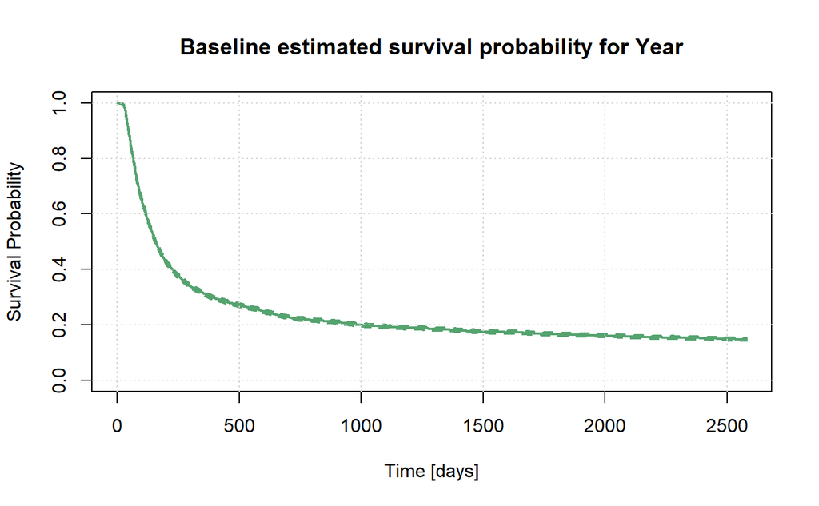

```r
#Plot (baseline survival function S0(t)):
plot(survfit(mfit.year, data=data),
     col="#55A36F", lwd=2, lty=1,
     xlab='Time [days]', ylab='Survival Probability',
     main='Baseline estimated survival probability for Year')
grid()
```

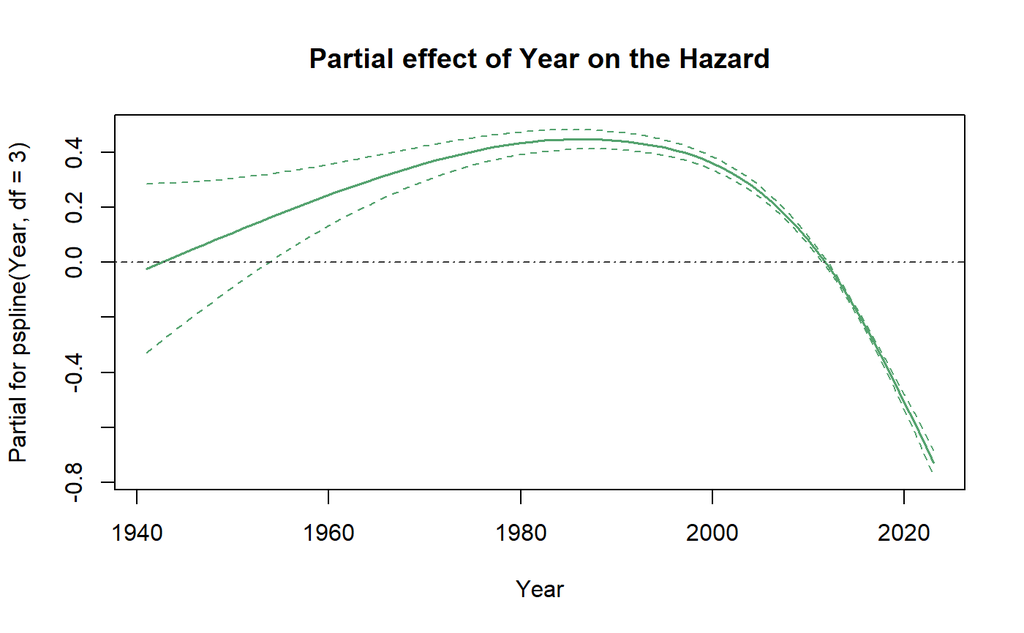

```r
termplot(mfit.year, term=1, se=TRUE, col.term='#55A36F', col.se='#55A36F', main = 'Partial effect of Year on the Hazard')
abline(h = 0, lty = 4, col = "#3A3A3A")
```

```r
#bspline:
mfit.year_bs <- coxph(Surv(time, status) ~ bs(Year, df=3), data=data)
mfit.year_bs
```

```
Call:
coxph(formula = Surv(time, status) ~ bs(Year, df = 3), data = data)

                     coef exp(coef) se(coef)      z        p
bs(Year, df = 3)1 -1.2679    0.2814   0.3479 -3.645 0.000268
bs(Year, df = 3)2  1.2496    3.4889   0.1684  7.421 1.16e-13
bs(Year, df = 3)3 -1.4069    0.2449   0.2141 -6.571 5.00e-11

Likelihood ratio test=1860  on 3 df, p=< 2.2e-16
n= 19936, number of events= 16715
```

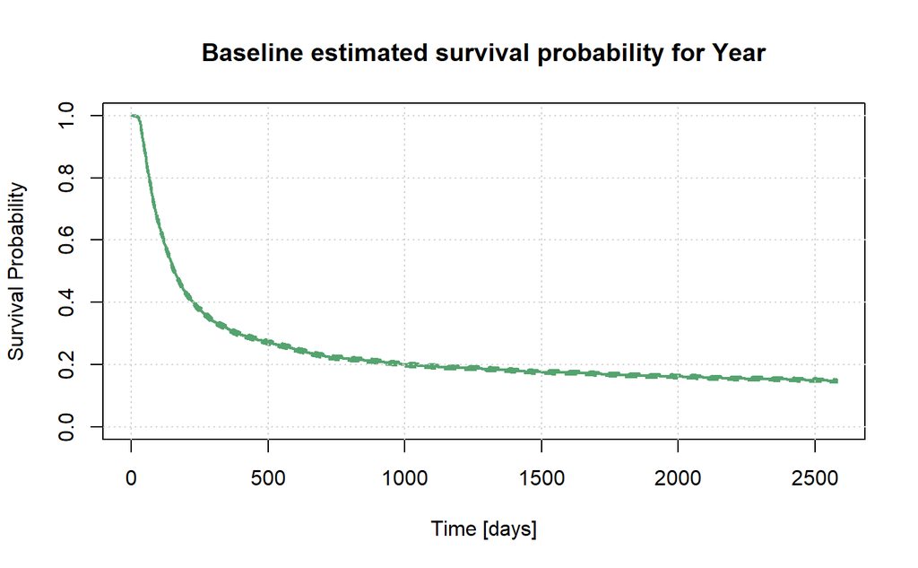

```r
#Plot (baseline survival function S0(t)):
plot(survfit(mfit.year_bs, data=data),
     col="#55A36F", lwd=2, lty=1,
     xlab='Time [days]', ylab='Survival Probability',
     main='Baseline estimated survival probability for Year')
grid()
```

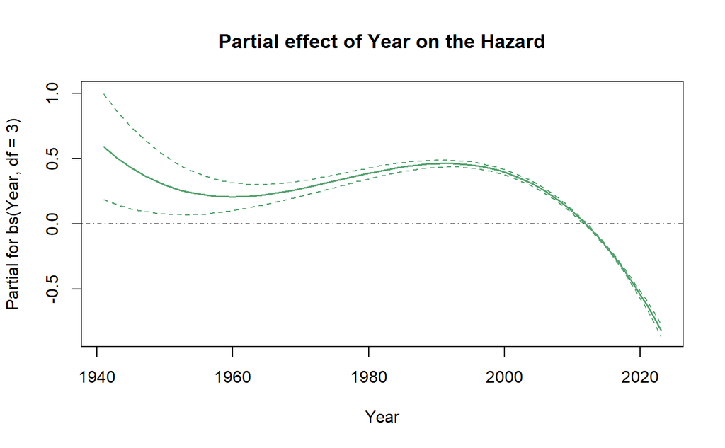

```r
termplot(mfit.year_bs, term=1, se=TRUE, col.term='#55A36F', col.se='#55A36F', main = 'Partial effect of Year on the Hazard')
abline(h = 0, lty = 4, col = "#3A3A3A")
```

```r
#natural spline:
mfit.year_ns <- coxph(Surv(time, status) ~ ns(Year, df=3), data=data)
mfit.year_ns
```

```
Call:
coxph(formula = Surv(time, status) ~ ns(Year, df = 3), data = data)

                      coef exp(coef) se(coef)       z      p
ns(Year, df = 3)1 -0.12783   0.88000  0.06220  -2.055 0.0399
ns(Year, df = 3)2 -0.05353   0.94787  0.23591  -0.227 0.8205
ns(Year, df = 3)3 -1.43055   0.23918  0.04694 -30.474 <2e-16

Likelihood ratio test=1933  on 3 df, p=< 2.2e-16
n= 19936, number of events= 16715
```

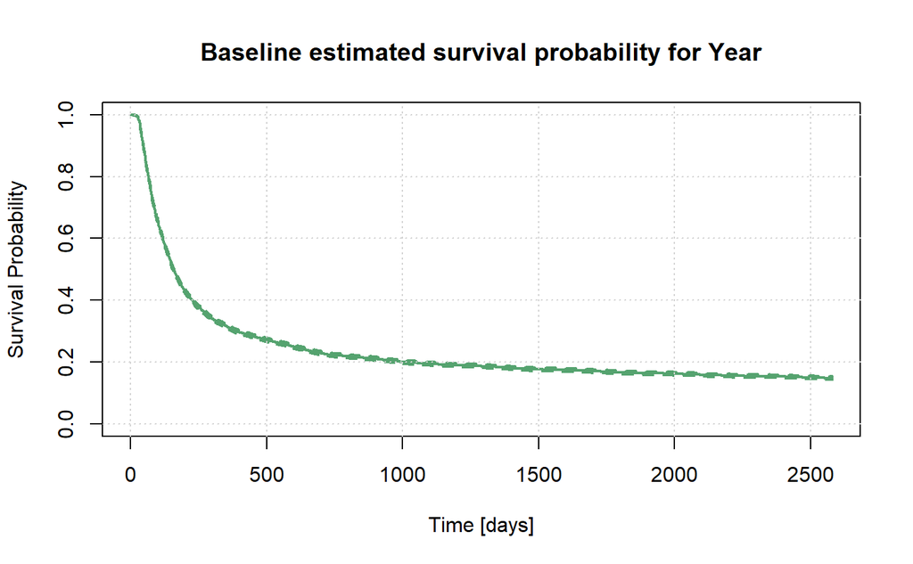

```r
#Plot (baseline survival function S0(t)):
plot(survfit(mfit.year_ns, data=data),
     col="#55A36F", lwd=2, lty=1,
     xlab='Time [days]', ylab='Survival Probability',
     main='Baseline estimated survival probability for Year')
grid()
```

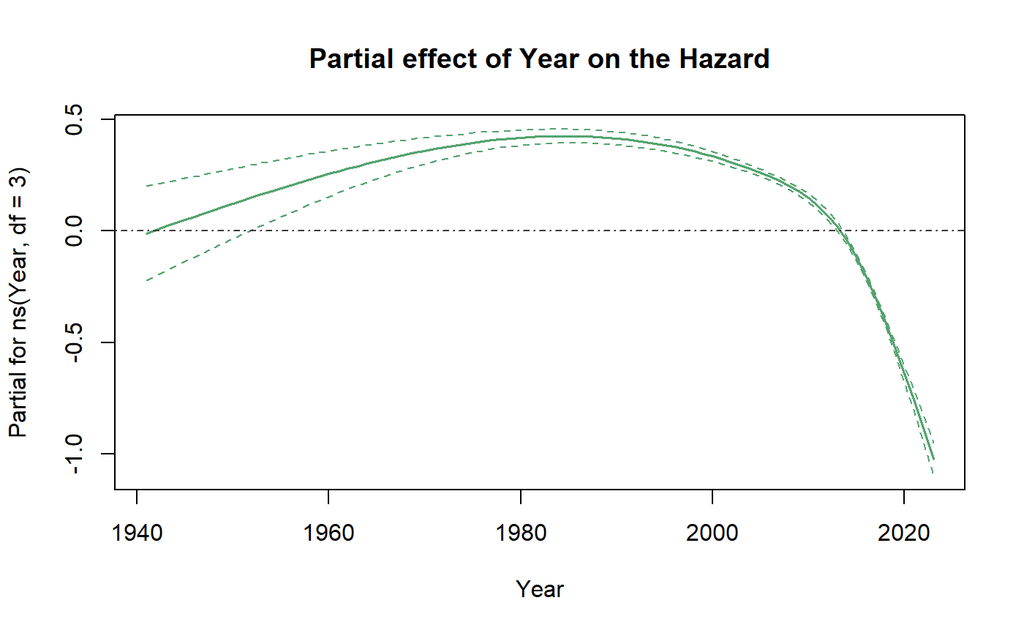

```r
termplot(mfit.year_ns, term=1, se=TRUE, col.term='#55A36F', col.se='#55A36F', main = 'Partial effect of Year on the Hazard')
abline(h = 0, lty = 4, col = "#3A3A3A")
```

```r
#rcs spline:
mfit.year_rcs <- coxph(Surv(time, status) ~ rcs(Year, df=5), data=data)
```

```
number of knots in rcs defaulting to 5
```

```r
mfit.year_rcs
```

```
Call:
coxph(formula = Surv(time, status) ~ rcs(Year, df = 5), data = data)

                              coef exp(coef)  se(coef)      z        p
rcs(Year, df = 5)Year     0.003201  1.003206  0.001694  1.889  0.05889
rcs(Year, df = 5)Year'   -0.021524  0.978706  0.003661 -5.879 4.13e-09
rcs(Year, df = 5)Year''  -0.006840  0.993184  0.075128 -0.091  0.92746
rcs(Year, df = 5)Year''' -1.301897  0.272015  0.450275 -2.891  0.00384

Likelihood ratio test=1925  on 4 df, p=< 2.2e-16
n= 19936, number of events= 16715
```

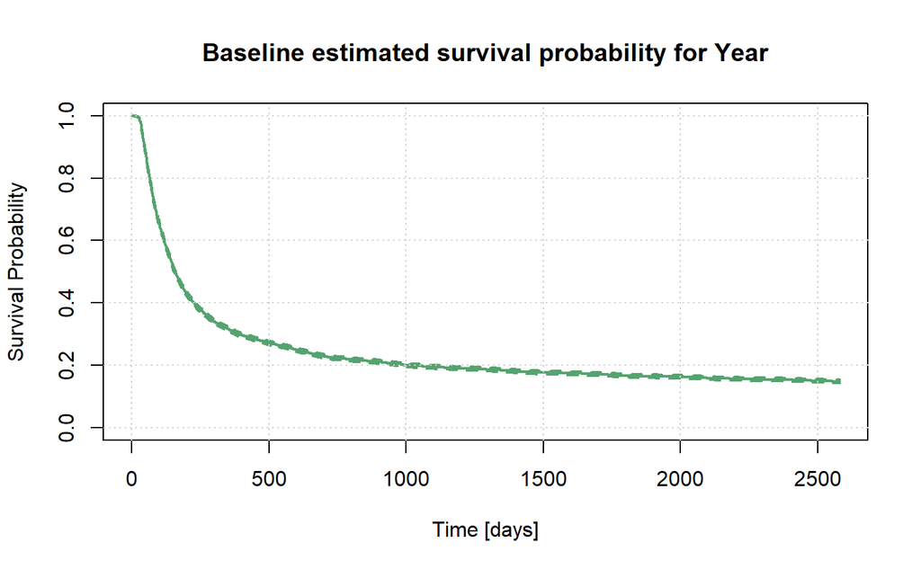

```r
#Plot (baseline survival function S0(t)):
plot(survfit(mfit.year_rcs, data=data),
     col="#55A36F", lwd=2, lty=1,
     xlab='Time [days]', ylab='Survival Probability',
     main='Baseline estimated survival probability for Year')
grid()
```

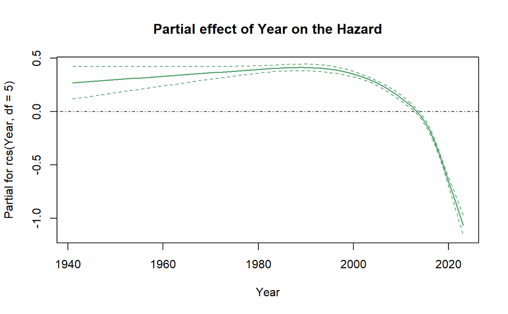

```r
termplot(mfit.year_rcs, term=1, se=TRUE, col.term='#55A36F', col.se='#55A36F', main = 'Partial effect of Year on the Hazard')
abline(h = 0, lty = 4, col = "#3A3A3A")
```

### 2.A) Minage

```r
#2.A)Minage:
#lin:
cox.minage <- coxph(Surv(time, status) ~ minage, data = data)
cox.minage
```

```
Call:
coxph(formula = Surv(time, status) ~ minage, data = data)

            coef exp(coef)  se(coef)      z      p
minage -0.050190  0.951049  0.002165 -23.19 <2e-16

Likelihood ratio test=510.8  on 1 df, p=< 2.2e-16
n= 19936, number of events= 16715
```

```r
summary(cox.minage)
```

```
Call:
coxph(formula = Surv(time, status) ~ minage, data = data)

  n= 19936, number of events= 16715

            coef exp(coef)  se(coef)      z Pr(>|z|)
minage -0.050190  0.951049  0.002165 -23.19   <2e-16 ***
---
Signif. codes:  0 ‘***’ 0.001 ‘**’ 0.01 ‘*’ 0.05 ‘.’ 0.1 ‘ ’ 1

       exp(coef) exp(-coef) lower .95 upper .95
minage     0.951      1.051     0.947    0.9551

Concordance= 0.548  (se = 0.002 )
Likelihood ratio test= 510.8  on 1 df,   p=<2e-16
Wald test            = 537.6  on 1 df,   p=<2e-16
Score (logrank) test = 537.8  on 1 df,   p=<2e-16
```

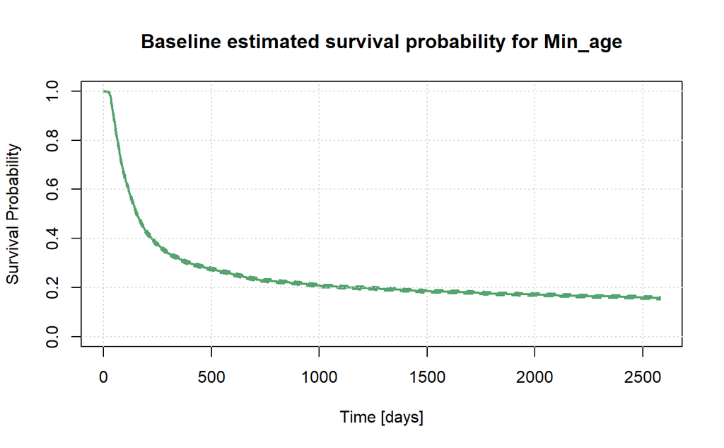

```r
#Plot (baseline survival function S0(t)):
plot(survfit(cox.minage, data=data),
     col="#55A36F", lwd=2, lty=1,
     xlab='Time [days]', ylab='Survival Probability',
     main='Baseline estimated survival probability for Min_age')
grid()
```

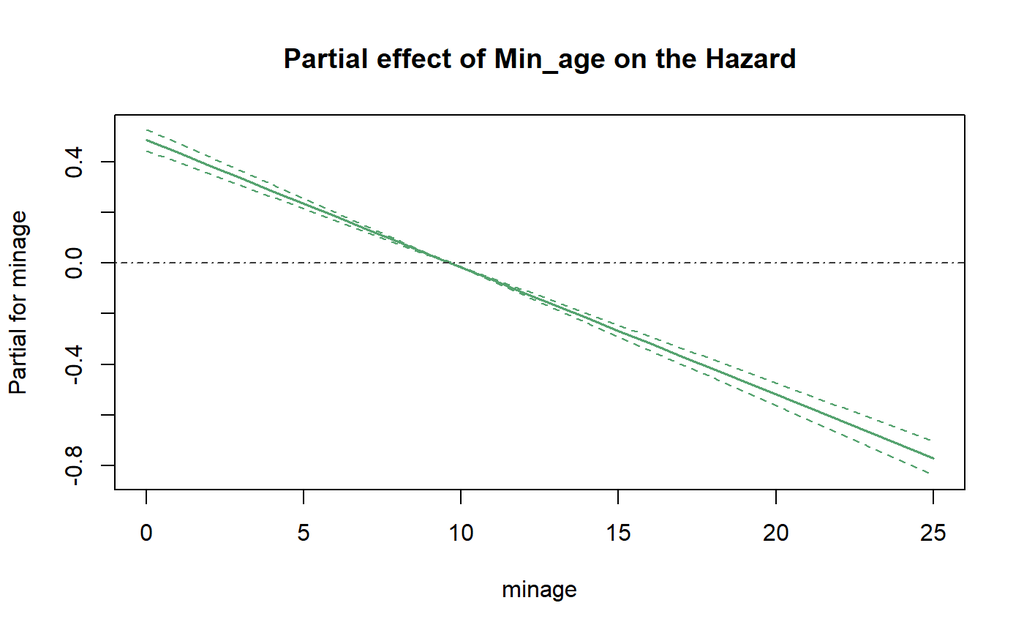

```r
termplot(cox.minage, term=1, se=TRUE, col.term='#55A36F', col.se='#55A36F', main = 'Partial effect of Min_age on the Hazard')
abline(h = 0, lty = 4, col = "#3A3A3A")
```

```r
#pspline:
mfit.minage <- coxph(Surv(time, status) ~ pspline(minage, df=3), data=data)
mfit.minage
```

```
Call:
coxph(formula = Surv(time, status) ~ pspline(minage, df = 3),
    data = data)

                               coef  se(coef)       se2     Chisq   DF       p
pspline(minage, df = 3),   -0.05015   0.00220   0.00214 520.32908 1.00 < 2e-16
pspline(minage, df = 3),                                 66.07651 2.08 5.3e-15

Iterations: 8 outer, 23 Newton-Raphson
     Theta= 0.996
Degrees of freedom for terms= 3.1
Likelihood ratio test=570  on 3.08 df, p=<2e-16
n= 19936, number of events= 16715
```

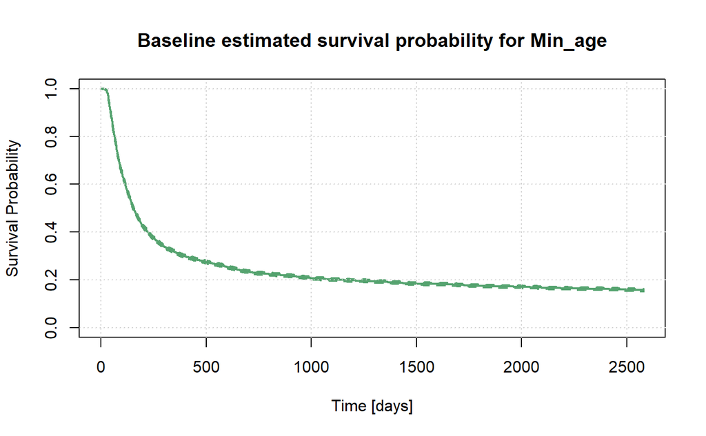

```r
#Plot (baseline survival function S0(t)):
plot(survfit(mfit.minage, data=data),
     col="#55A36F", lwd=2, lty=1,
     xlab='Time [days]', ylab='Survival Probability',
     main='Baseline estimated survival probability for Min_age')
grid()
```

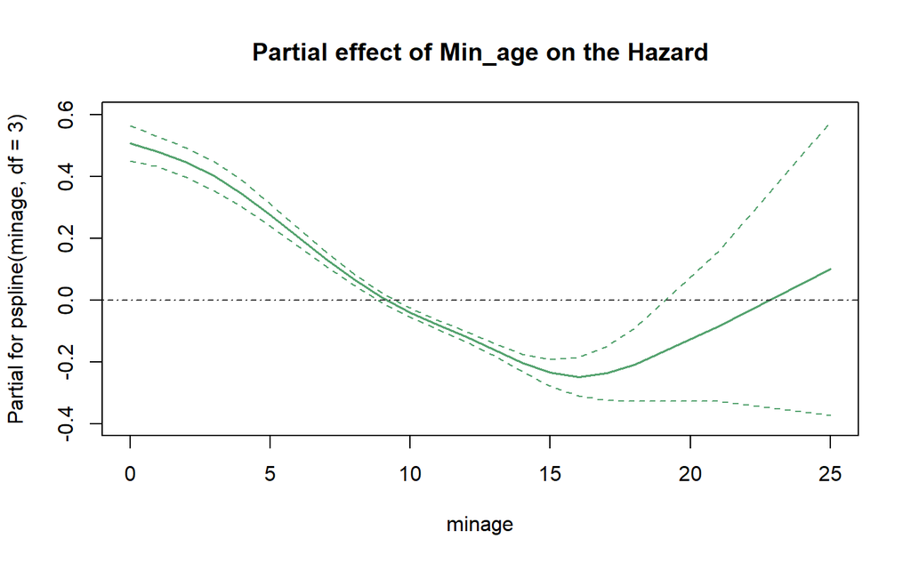

```r
termplot(mfit.minage, term=1, se=TRUE, col.term='#55A36F', col.se='#55A36F', main = 'Partial effect of Min_age on the Hazard')
abline(h = 0, lty = 4, col = "#3A3A3A")
```

```r
#bspline:
mfit.minage_bs <- coxph(Surv(time, status) ~ bs(minage, df=3), data=data)
mfit.minage_bs
```

```
Call:
coxph(formula = Surv(time, status) ~ bs(minage, df = 3), data = data)

                        coef exp(coef) se(coef)       z       p
bs(minage, df = 3)1 -0.01642   0.98371  0.11157  -0.147 0.88298
bs(minage, df = 3)2 -2.06321   0.12705  0.20339 -10.144 < 2e-16
bs(minage, df = 3)3  1.00900   2.74285  0.35089   2.876 0.00403

Likelihood ratio test=549.3  on 3 df, p=< 2.2e-16
n= 19936, number of events= 16715
```

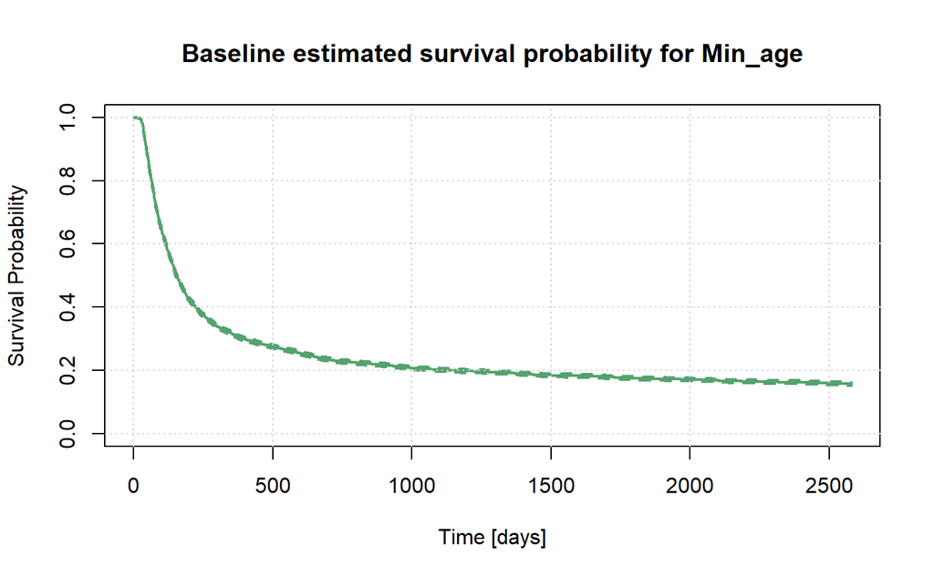

```r
#Plot (baseline survival function S0(t)):
plot(survfit(mfit.minage_bs, data=data),
     col="#55A36F", lwd=2, lty=1,
     xlab='Time [days]', ylab='Survival Probability',
     main='Baseline estimated survival probability for Min_age')
grid()
```

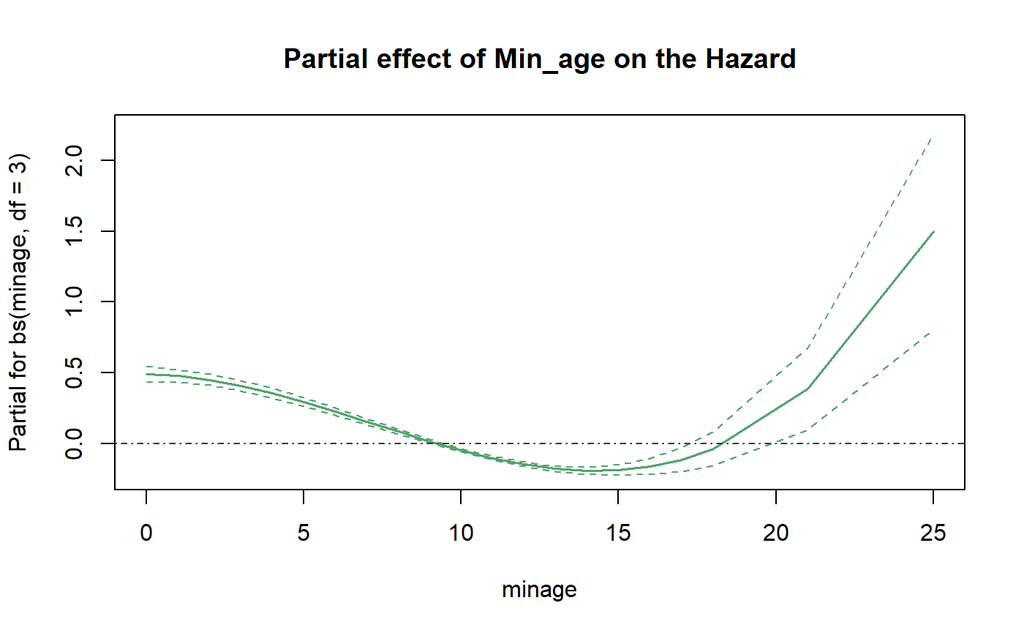

```r
termplot(mfit.minage_bs, term=1, se=TRUE, col.term='#55A36F', col.se='#55A36F', main = 'Partial effect of Min_age on the Hazard')
abline(h = 0, lty = 4, col = "#3A3A3A")
```

```r
#natural spline:
mfit.minage_ns <- coxph(Surv(time, status) ~ ns(minage, df=3), data=data)
mfit.minage_ns
```

```
Call:
coxph(formula = Surv(time, status) ~ ns(minage, df = 3), data = data)

                        coef exp(coef) se(coef)       z        p
ns(minage, df = 3)1 -0.73513   0.47944  0.04942 -14.874  < 2e-16
ns(minage, df = 3)2 -0.95375   0.38530  0.15016  -6.351 2.13e-10
ns(minage, df = 3)3 -0.28728   0.75030  0.23543  -1.220    0.222

Likelihood ratio test=525.5  on 3 df, p=< 2.2e-16
n= 19936, number of events= 16715
```

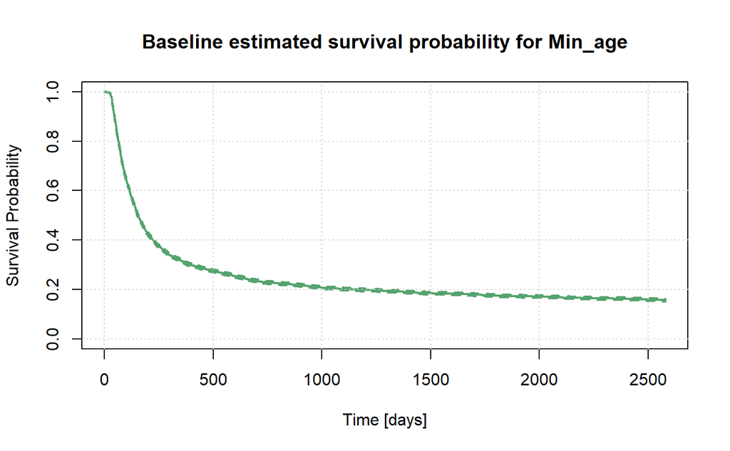

```r
#Plot (baseline survival function S0(t)):
plot(survfit(mfit.minage_ns, data=data),
     col="#55A36F", lwd=2, lty=1,
     xlab='Time [days]', ylab='Survival Probability',
     main='Baseline estimated survival probability for Min_age')
grid()
```

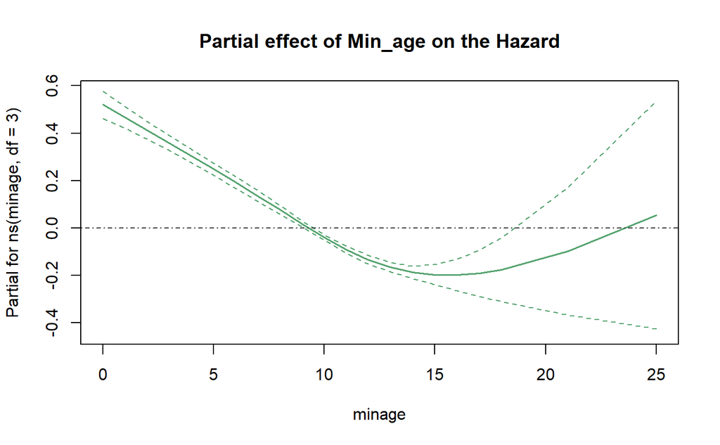

```r
termplot(mfit.minage_ns, term=1, se=TRUE, col.term='#55A36F', col.se='#55A36F', main = 'Partial effect of Min_age on the Hazard')
abline(h = 0, lty = 4, col = "#3A3A3A")
```

```r
#rcs spline:
mfit.minage_rcs <- coxph(Surv(time, status) ~ rcs(minage, df=5), data=data)
```

```
number of knots in rcs defaulting to 5
```

```r
mfit.minage_rcs
```

```
Call:
coxph(formula = Surv(time, status) ~ rcs(minage, df = 5), data = data)

                                  coef exp(coef)  se(coef)      z        p
rcs(minage, df = 5)minage    -0.035087  0.965522  0.008429 -4.162 3.15e-05
rcs(minage, df = 5)minage'   -0.064200  0.937817  0.017095 -3.756 0.000173
rcs(minage, df = 5)minage''   1.864761  6.454394  0.330775  5.638 1.72e-08
rcs(minage, df = 5)minage''' -4.765263  0.008521  0.787320 -6.053 1.43e-09

Likelihood ratio test=553.9  on 4 df, p=< 2.2e-16
n= 19936, number of events= 16715
```

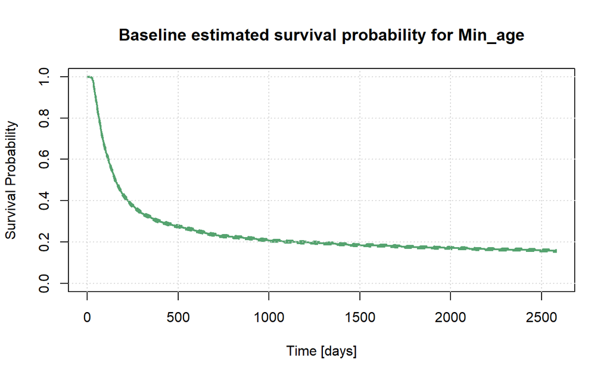

```r
#Plot (baseline survival function S0(t)):
plot(survfit(mfit.minage_rcs, data=data),
     col="#55A36F", lwd=2, lty=1,
     xlab='Time [days]', ylab='Survival Probability',
     main='Baseline estimated survival probability for Min_age')
grid()
```

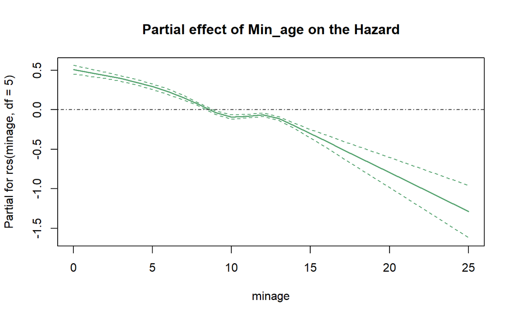

```r
termplot(mfit.minage_rcs, term=1, se=TRUE, col.term='#55A36F', col.se='#55A36F', main = 'Partial effect of Min_age on the Hazard')
abline(h = 0, lty = 4, col = "#3A3A3A")
```

### 3.A) Playing_time

```r
#3.A)playingtime:
#lin:
cox.playingtime <- coxph(Surv(time, status) ~ playingtime, data = data)
cox.playingtime
```

```
Call:
coxph(formula = Surv(time, status) ~ playingtime, data = data)

                 coef exp(coef)  se(coef)     z     p
playingtime 6.882e-06 1.000e+00 1.238e-04 0.056 0.956

Likelihood ratio test=0  on 1 df, p=0.9557
n= 19936, number of events= 16715
```

```r
summary(cox.playingtime)
```

```
Call:
coxph(formula = Surv(time, status) ~ playingtime, data = data)

  n= 19936, number of events= 16715

                 coef exp(coef)  se(coef)     z Pr(>|z|)
playingtime 6.882e-06 1.000e+00 1.238e-04 0.056    0.956

            exp(coef) exp(-coef) lower .95 upper .95
playingtime         1          1    0.9998         1

Concordance= 0.472  (se = 0.002 )
Likelihood ratio test= 0  on 1 df,   p=1
Wald test            = 0  on 1 df,   p=1
Score (logrank) test = 0  on 1 df,   p=1
```

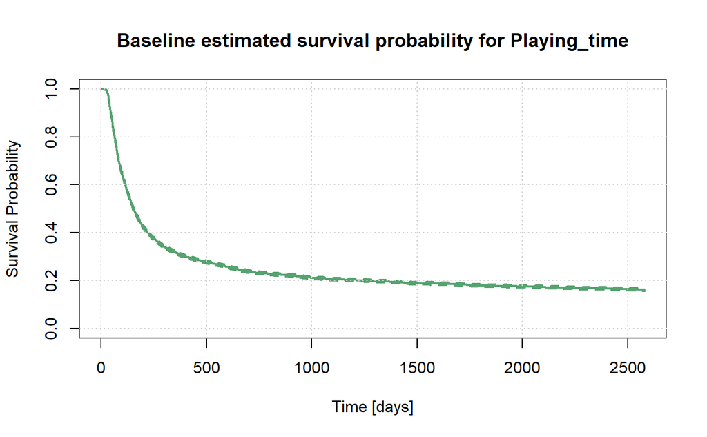

```r
#Plot (baseline survival function S0(t)):
plot(survfit(cox.playingtime, data=data),
     col="#55A36F", lwd=2, lty=1,
     xlab='Time [days]', ylab='Survival Probability',
     main='Baseline estimated survival probability for Playing_time')
grid()
```

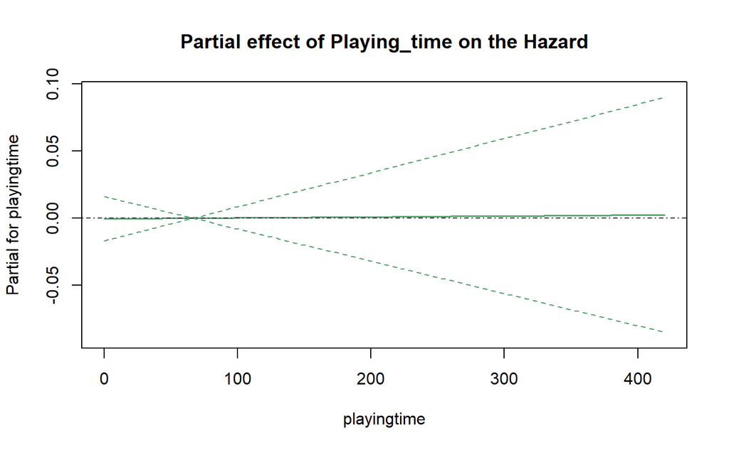

```r
termplot(cox.playingtime, term=1, se=TRUE, col.term='#55A36F', col.se='#55A36F', main = 'Partial effect of Playing_time on the Hazard')
abline(h = 0, lty = 4, col = "#3A3A3A") #lin not sign
```

```r
#psline:
mfit.playingtime <- coxph(Surv(time, status) ~ pspline(playingtime, df=3), data=data)
mfit.playingtime
```

```
Call:
coxph(formula = Surv(time, status) ~ pspline(playingtime, df = 3),
    data = data)

                              coef se(coef)      se2    Chisq   DF      p
pspline(playingtime, df = 1.67e-04 1.12e-04 1.11e-04 2.23e+00 1.00   0.14
pspline(playingtime, df =                            4.40e+02 2.06 <2e-16

Iterations: 9 outer, 20 Newton-Raphson
     Theta= 0.997
Degrees of freedom for terms= 3.1
Likelihood ratio test=501  on 3.06 df, p=<2e-16
n= 19936, number of events= 16715
```

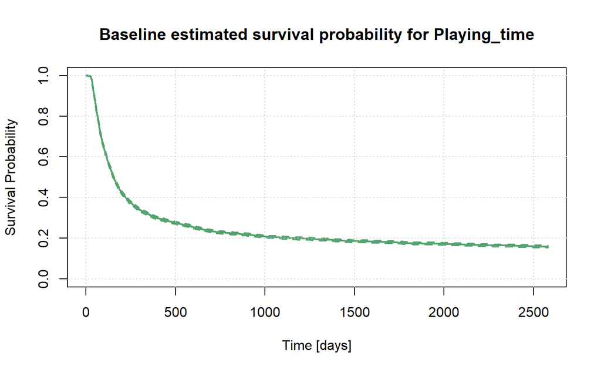

```r
#Plot (baseline survival function S0(t)):
plot(survfit(mfit.playingtime, data=data),
     col="#55A36F", lwd=2, lty=1,
     xlab='Time [days]', ylab='Survival Probability',
     main='Baseline estimated survival probability for Playing_time')
grid()
```

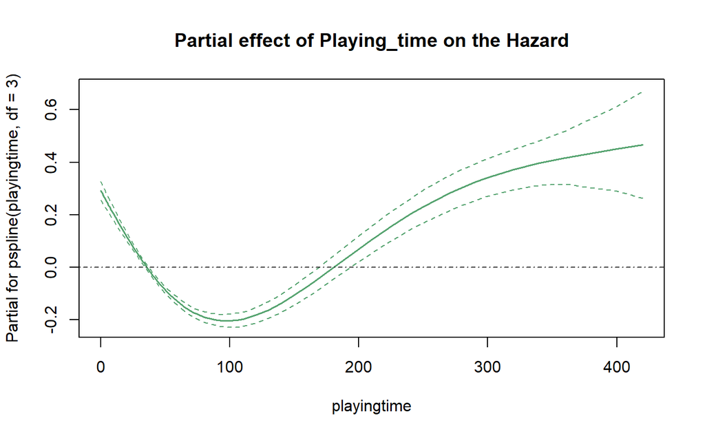

```r
termplot(mfit.playingtime, term=1, se=TRUE, col.term='#55A36F', col.se='#55A36F', main = 'Partial effect of Playing_time on the Hazard')
abline(h = 0, lty = 4, col = "#3A3A3A")
```

```r
#bspline:
mfit.playingtime_bs <- coxph(Surv(time, status) ~ bs(playingtime, df=3), data=data)
mfit.playingtime_bs
```

```
Call:
coxph(formula = Surv(time, status) ~ bs(playingtime, df = 3),
    data = data)

                             coef exp(coef) se(coef)       z        p
bs(playingtime, df = 3)1 -2.00609   0.13451  0.09561 -20.981  < 2e-16
bs(playingtime, df = 3)2  1.71678   5.56658  0.14387  11.933  < 2e-16
bs(playingtime, df = 3)3 -0.77528   0.46058  0.14401  -5.383 7.31e-08

Likelihood ratio test=530.2  on 3 df, p=< 2.2e-16
n= 19936, number of events= 16715
```

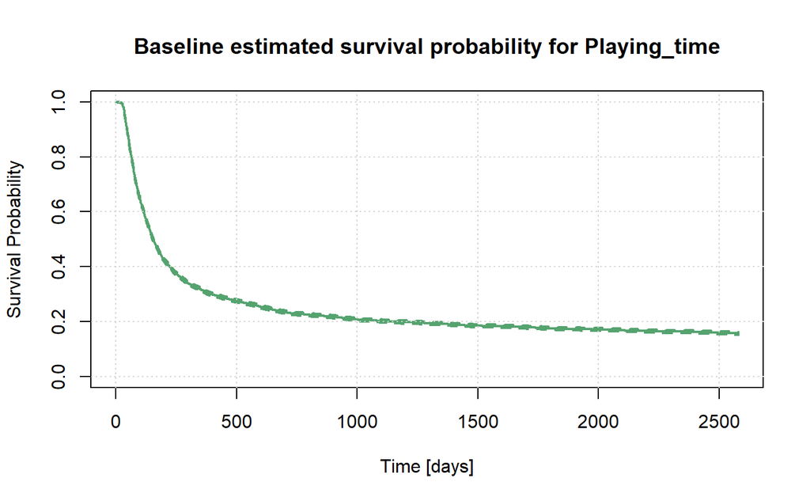

```r
#Plot (baseline survival function S0(t)):
plot(survfit(mfit.playingtime_bs, data=data),
     col="#55A36F", lwd=2, lty=1,
     xlab='Time [days]', ylab='Survival Probability',
     main='Baseline estimated survival probability for Playing_time')
grid()
```

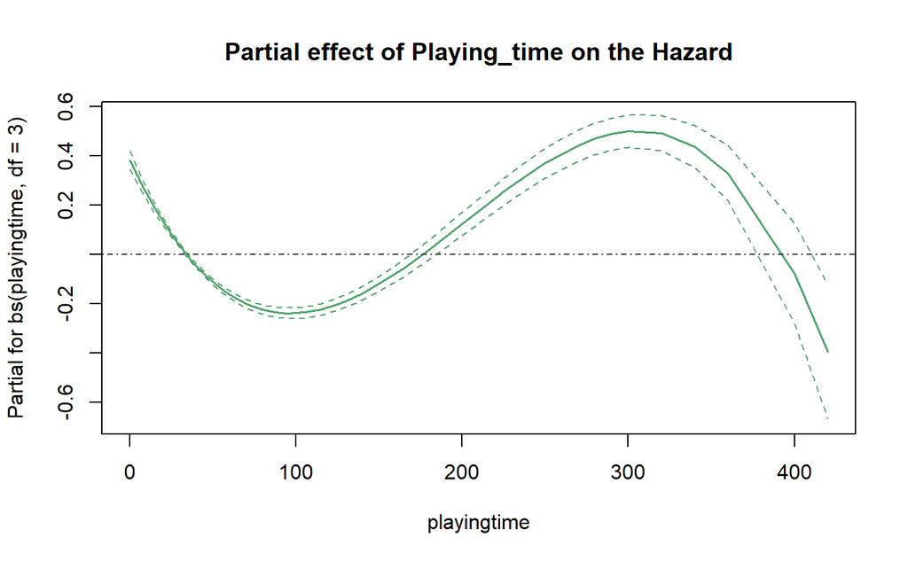

```r
termplot(mfit.playingtime_bs, term=1, se=TRUE, col.term='#55A36F', col.se='#55A36F', main = 'Partial effect of Playing_time on the Hazard')
abline(h = 0, lty = 4, col = "#3A3A3A")
```

```r
#natural spline:
mfit.playingtime_ns <- coxph(Surv(time, status) ~ ns(playingtime, df=3), data=data)
mfit.playingtime_ns
```

```
Call:
coxph(formula = Surv(time, status) ~ ns(playingtime, df = 3),
    data = data)

                             coef exp(coef) se(coef)       z        p
ns(playingtime, df = 3)1 -0.45021   0.63749  0.04598  -9.791  < 2e-16
ns(playingtime, df = 3)2 -0.81053   0.44462  0.06391 -12.682  < 2e-16
ns(playingtime, df = 3)3  0.49120   1.63428  0.06919   7.100 1.25e-12

Likelihood ratio test=525.8  on 3 df, p=< 2.2e-16
n= 19936, number of events= 16715
```